# IODS course project

Eeva Vakkari

# Introduction to Open Data Science - Course Project

# Assignment 1

**Eeva Vakkari**

https://github.com/EevaVakkari/IODS-project

```r
date()
```

```
## [1] "Mon Nov 20 16:06:49 2023"
```

## Some feelings after the first week

It has been quite a heavy crash course into the world of R. The book is good, especially with the exercises and notes in the markdown file, but it’s massive for a beginner.

With the R syntax, I still feel almost as if I was illiterate, but I trust I’ll get used to R jargon with time and more exercises.

## My aims for the course

After this course, I wish I could work somewhat independently, at least with very basic things, in R. I aim to familiarize myself with it at least to the level where I’ll be able to understand the error messages I get and the solutions I google.

# Assignment 2

**Eeva Vakkari**

https://github.com/EevaVakkari/IODS-project

## Introduction and overview

This week, I studied linear regression using a survey data set combined with exam results from a university statistics course. I made a simple linear model and validated it graphically. First two code blocks contain the data wrangling part and, after them, the analysis part starts.

## Data wrangling

```r
date()
```

```
## [1] "Mon Nov 20 16:06:50 2023"
```

I performed the data wrangling as instructed:

```r
library(tidyverse)
lrn14 <- read.table("http://www.helsinki.fi/~kvehkala/JYTmooc/JYTOPKYS3-data.txt", sep="\t", header=TRUE)
lrn14$attitude <- lrn14$Attitude / 10
deep_questions <- c("D03", "D11", "D19", "D27", "D07", "D14", "D22", "D30","D06",  "D15", "D23", "D31")
lrn14$deep <- rowMeans(lrn14[, deep_questions])
surface_questions <- c("SU02","SU10","SU18","SU26", "SU05","SU13","SU21","SU29","SU08","SU16","SU24","SU32")
lrn14$surf <- rowMeans(lrn14[, surface_questions])
strategic_questions <- c("ST01","ST09","ST17","ST25","ST04","ST12","ST20","ST28")
lrn14$stra <- rowMeans(lrn14[, strategic_questions])
str(lrn14)
```

```
## 'data.frame':    183 obs. of  64 variables:
##  $ Aa      : int  3 2 4 4 3 4 4 3 2 3 ...
##  $ Ab      : int  1 2 1 2 2 2 1 1 1 2 ...
##  $ Ac      : int  2 2 1 3 2 1 2 2 2 1 ...
##  $ Ad      : int  1 2 1 2 1 1 2 1 1 1 ...
##  $ Ae      : int  1 1 1 1 2 1 1 1 1 1 ...
##  $ Af      : int  1 1 1 1 1 1 1 1 1 2 ...
##  $ ST01    : int  4 4 3 3 4 4 5 4 4 4 ...
##  $ SU02    : int  2 2 1 3 2 3 2 2 1 2 ...
##  $ D03     : int  4 4 4 4 5 5 4 4 5 4 ...
##  $ ST04    : int  4 4 4 4 3 4 2 5 5 4 ...
##  $ SU05    : int  2 4 2 3 4 3 2 4 2 4 ...
##  $ D06     : int  4 2 3 4 4 5 3 3 4 4 ...
##  $ D07     : int  4 3 4 4 4 5 4 4 5 4 ...
##  $ SU08    : int  3 4 1 2 3 4 4 2 4 2 ...
```

[output cut: 50 more lines]

```r
dim(lrn14)
```

```
## [1] 183  64
```

At this point, the data set consists of 63 numerical and 1 character variables. All together 183 observations. Now, let’s focus on a subset of the data:

```r
library(dplyr)
keep_columns <- c("gender","Age","Attitude", "deep", "stra", "surf", "Points")
analysis <- select(lrn14, one_of(keep_columns))
analysis <- filter_if(analysis, is.numeric, all_vars((.) != 0)) #removing all zeros
setwd("~/Polyembryony_R/IODS/IODS-project/data")
write.csv(analysis, "learning2014.csv", row.names = F)
a <- read.csv("learning2014.csv") #Checking that csv is OK.
str(a)
```

```
## 'data.frame':    166 obs. of  7 variables:
##  $ gender  : chr  "F" "M" "F" "M" ...
##  $ Age     : int  53 55 49 53 49 38 50 37 37 42 ...
##  $ Attitude: int  37 31 25 35 37 38 35 29 38 21 ...
##  $ deep    : num  3.58 2.92 3.5 3.5 3.67 ...
##  $ stra    : num  3.38 2.75 3.62 3.12 3.62 ...
##  $ surf    : num  2.58 3.17 2.25 2.25 2.83 ...
##  $ Points  : int  25 12 24 10 22 21 21 31 24 26 ...
```

```r
head(a)
```

```
##   gender Age Attitude     deep  stra     surf Points
## 1      F  53       37 3.583333 3.375 2.583333     25
## 2      M  55       31 2.916667 2.750 3.166667     12
## 3      F  49       25 3.500000 3.625 2.250000     24
## 4      M  53       35 3.500000 3.125 2.250000     10
## 5      M  49       37 3.666667 3.625 2.833333     22
## 6      F  38       38 4.750000 3.625 2.416667     21
```

Looking good. Continuing into analysis part of the assignment.

## Data analysis

Setting the working directory and reading the csv into a data frame:

```r
setwd("~/Polyembryony_R/IODS/IODS-project/data")
learning2014 <- read.csv("learning2014.csv")
str(learning2014)
```

```
## 'data.frame':    166 obs. of  7 variables:
##  $ gender  : chr  "F" "M" "F" "M" ...
##  $ Age     : int  53 55 49 53 49 38 50 37 37 42 ...
##  $ Attitude: int  37 31 25 35 37 38 35 29 38 21 ...
##  $ deep    : num  3.58 2.92 3.5 3.5 3.67 ...
##  $ stra    : num  3.38 2.75 3.62 3.12 3.62 ...
##  $ surf    : num  2.58 3.17 2.25 2.25 2.83 ...
##  $ Points  : int  25 12 24 10 22 21 21 31 24 26 ...
```

```r
head(learning2014)
```

```
##   gender Age Attitude     deep  stra     surf Points
## 1      F  53       37 3.583333 3.375 2.583333     25
## 2      M  55       31 2.916667 2.750 3.166667     12
## 3      F  49       25 3.500000 3.625 2.250000     24
## 4      M  53       35 3.500000 3.125 2.250000     10
## 5      M  49       37 3.666667 3.625 2.833333     22
## 6      F  38       38 4.750000 3.625 2.416667     21
```

The data consists of learning approach survey results combined with student success in the exam. There are 7 variables and 166 observations.

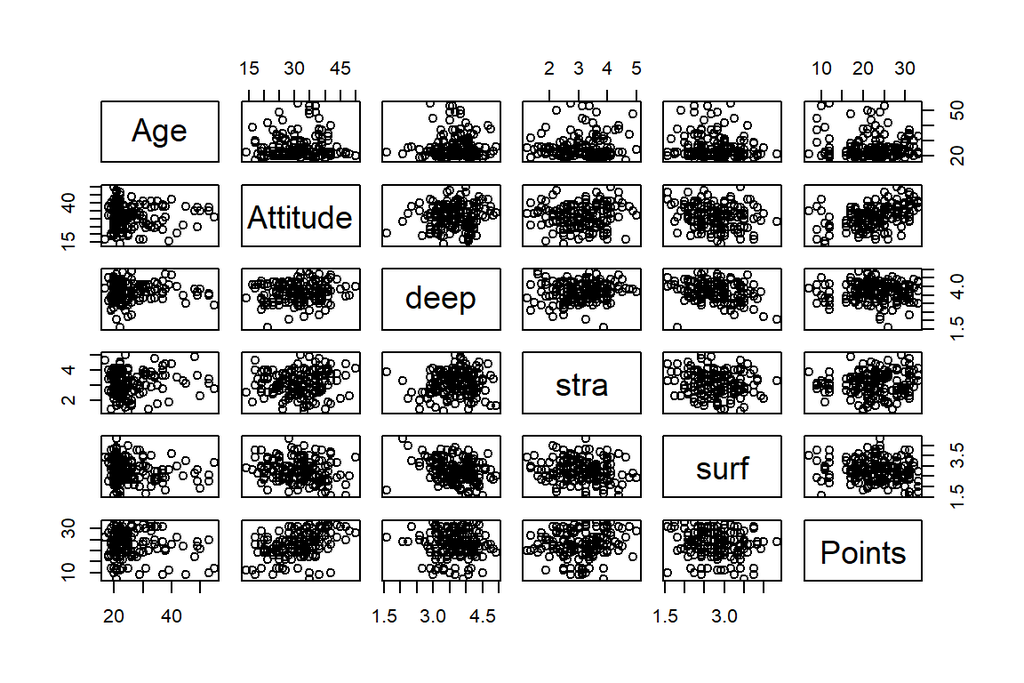

```r
pairs(learning2014[-1])
```

```r
library(GGally)
```

```r
library(ggplot2)
p <- ggpairs(learning2014, mapping = aes(), lower = list(combo = wrap("facethist", bins = 20)))
```

Exam success, as represented by “Points”, seems to correlate with attitude. Other plots do not suggest strong correlations between the variables. Let’s study attitude, age and gender as explanatory variables for exam points.

```r
my_model1 <- lm(Points ~ Attitude + Age + gender, data = learning2014)
summary(my_model1)
```

```
##
## Call:
## lm(formula = Points ~ Attitude + Age + gender, data = learning2014)
##
## Residuals:
##      Min       1Q   Median       3Q      Max
## -17.4590  -3.3221   0.2186   4.0247  10.4632
##
## Coefficients:
##             Estimate Std. Error t value Pr(>|t|)
## (Intercept) 13.42910    2.29043   5.863 2.48e-08 ***
## Attitude     0.36066    0.05932   6.080 8.34e-09 ***
## Age         -0.07586    0.05367  -1.414    0.159
## genderM     -0.33054    0.91934  -0.360    0.720
## ---
## Signif. codes:  0 '***' 0.001 '**' 0.01 '*' 0.05 '.' 0.1 ' ' 1
##
## Residual standard error: 5.315 on 162 degrees of freedom
## Multiple R-squared:  0.2018, Adjusted R-squared:  0.187
## F-statistic: 13.65 on 3 and 162 DF,  p-value: 5.536e-08
```

When studied with two-sided Student’s t-test, it seems that only attitude has statistically significant effect on exam points whereas age and gender do not explain the exam success. Attitude correlates positively with exam points: with better attitude, the exam points tend to be higher. Making a new model with attitude as the only explanatory variable.

```r
my_model2 <- lm(Points ~ Attitude, data = learning2014)
summary(my_model2)
```

```
##
## Call:
## lm(formula = Points ~ Attitude, data = learning2014)
##
## Residuals:
##      Min       1Q   Median       3Q      Max
## -16.9763  -3.2119   0.4339   4.1534  10.6645
##
## Coefficients:
##             Estimate Std. Error t value Pr(>|t|)
## (Intercept) 11.63715    1.83035   6.358 1.95e-09 ***
## Attitude     0.35255    0.05674   6.214 4.12e-09 ***
## ---
## Signif. codes:  0 '***' 0.001 '**' 0.01 '*' 0.05 '.' 0.1 ' ' 1
##
## Residual standard error: 5.32 on 164 degrees of freedom
## Multiple R-squared:  0.1906, Adjusted R-squared:  0.1856
## F-statistic: 38.61 on 1 and 164 DF,  p-value: 4.119e-09
```

Also, the second model shows that attitude clearly has a statistically significant, positive correlation with exam points. Removing age and gender from the model drops adjusted R-squared value by 0.0014, indicating a very minor (i.e. insignificant) drop in the power of the model. Making diagnostic plots with the second model.

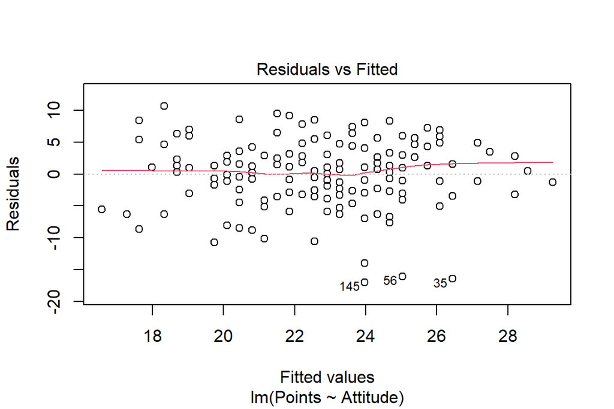

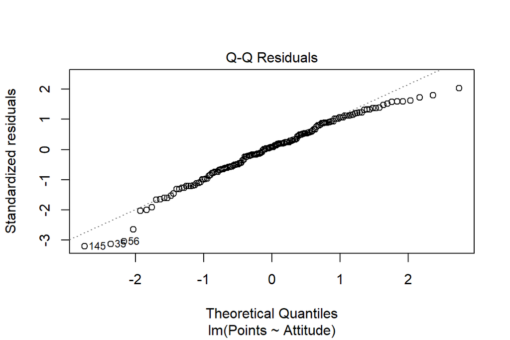

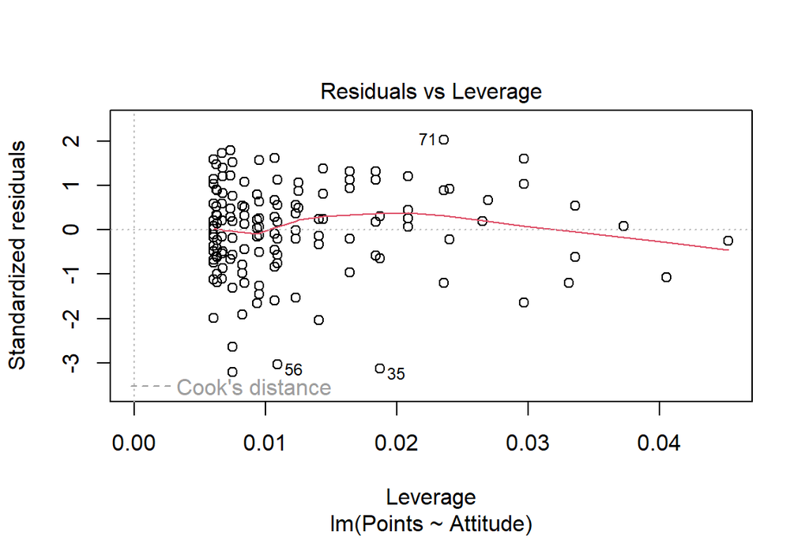

```r
plot(my_model2, which = c(1, 2, 5))
```

## Model evaluation

Linear regression model is based on four assumptions: 1. There is a linear relationship between predictor(s) and outcome 2. The residuals are independent 3. The residuals are normally distributed 4. The residuals have equal variance As demonstrated before, the attitude and exam points have linear relationship. We can confidently assume that residuals are independent since the original survey is represent individual students at a single time point, i.e. autocorrelation is not a concern. This is seen as a flat line in the residuals vs. fitted values plot. The Q-Q plot shows that the residuals are not completely normally distributed but quite close to it. The residuals vs leverage plot shows that all data points are nowhere close to Cook’s distance, i.e. don’t have high leverage. So, there are no too influential single data points.

# Assignment 3

**Eeva Vakkari**

https://github.com/EevaVakkari/IODS-project

## Introduction and overview

This week we practice logistic regression with a survey study combining alcohol consumption and student’s grades, as well as demographic, social and school related features. The data was uploaded from from UCI machine learning repository http://www.archive.ics.uci.edu/dataset/320/student+performance

```r
date()
```

```
## [1] "Mon Nov 20 16:07:00 2023"
```

```r
library(tidyverse)
library(dplyr)
library(readr)
```

Reading joined and modified data in and checking out the column names:

```r
setwd("~/Polyembryony_R/IODS/IODS-project/data")
alc <- read_csv("~/Polyembryony_R/IODS/IODS-project/data/alc.csv")
```

```
## ──────────────────────────────────────────────────────── Delimiter: "," chr
## (17): school, sex, address, famsize, Pstatus, Mjob, Fjob, reason, guardi... dbl
## (18): ...1, age, Medu, Fedu, traveltime, studytime, famrel, freetime, go... lgl
## (1): high_use
```

```r
head(alc)
```

```
## # A tibble: 6 × 36
##    ...1 school sex     age address famsize Pstatus  Medu  Fedu Mjob     Fjob
##   <dbl> <chr>  <chr> <dbl> <chr>   <chr>   <chr>   <dbl> <dbl> <chr>    <chr>
## 1     1 GP     F        18 U       GT3     A           4     4 at_home  teacher
## 2     2 GP     F        17 U       GT3     T           1     1 at_home  other
## 3     3 GP     F        15 U       LE3     T           1     1 at_home  other
## 4     4 GP     F        15 U       GT3     T           4     2 health   services
## 5     5 GP     F        16 U       GT3     T           3     3 other    other
## 6     6 GP     M        16 U       LE3     T           4     3 services other
## # ℹ 25 more variables: reason <chr>, guardian <chr>, traveltime <dbl>,
## #   studytime <dbl>, schoolsup <chr>, famsup <chr>, activities <chr>,
## #   nursery <chr>, higher <chr>, internet <chr>, romantic <chr>, famrel <dbl>,
## #   freetime <dbl>, goout <dbl>, Dalc <dbl>, Walc <dbl>, health <dbl>,
## #   failures <dbl>, paid <chr>, absences <dbl>, G1 <dbl>, G2 <dbl>, G3 <dbl>,
## #   alc_use <dbl>, high_use <lgl>
```

## Analysis of student’s high alcohol consumption

I study sex, age, absences and home address (urban/rural) as explanatory factors for a student’s alcohol consumption. I hypothesize that the younger female students having more absences and living in the rural locations consume the highest amount of alcohol. I assume all the variables have equal, additive effect on the response variable. Let’s explore the data:

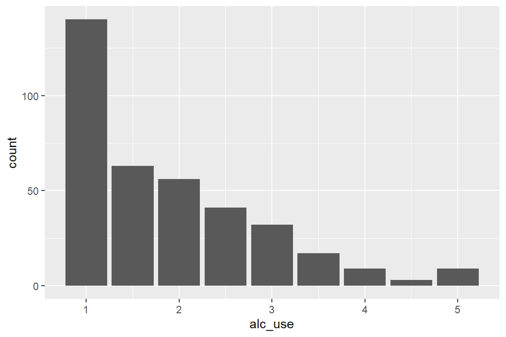

```r
g1 <- ggplot(data = alc, aes(x = alc_use))
g1 + geom_bar()
```

It seems that the majority uses relatively low amount of alcohol.

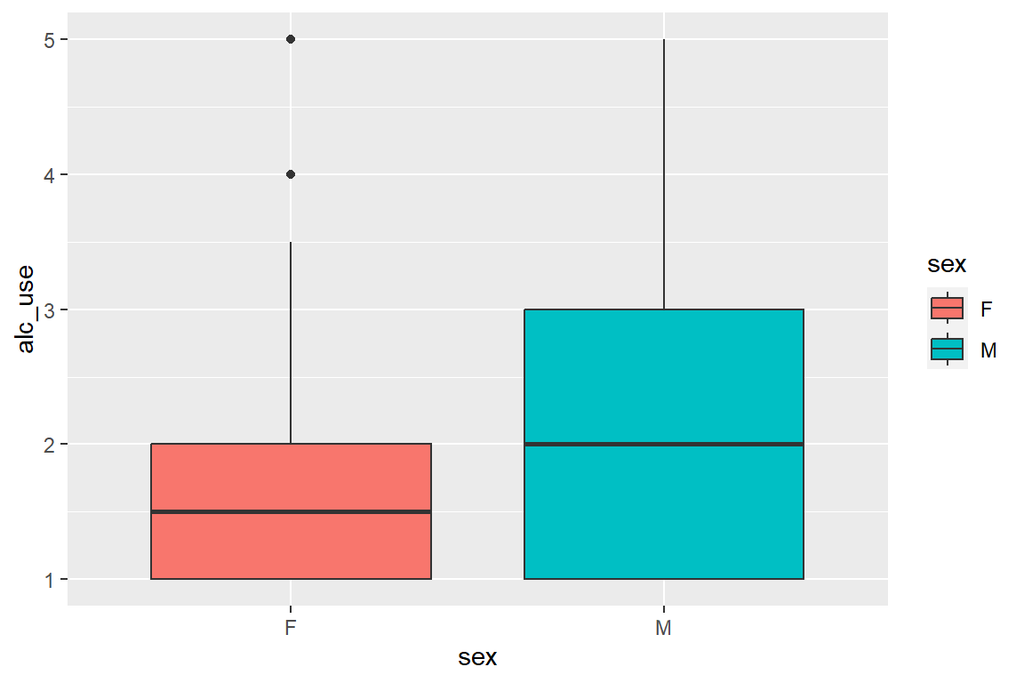

```r
g2 <- ggplot(alc, aes(x = sex, y = alc_use, fill=sex))+
  geom_boxplot()
g2
```

Surprisingly, this might indicate that my hypothesis about females consuming more alcohol might not be correct. I’ll study this strange thing more in detail.

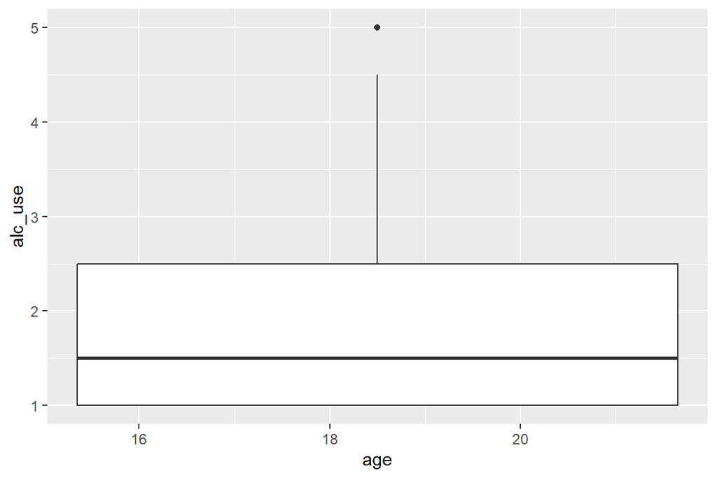

```r
g3 <- ggplot(alc, aes(x = age, y = alc_use))+
  geom_boxplot()
g3
```

Not so informative plot type.

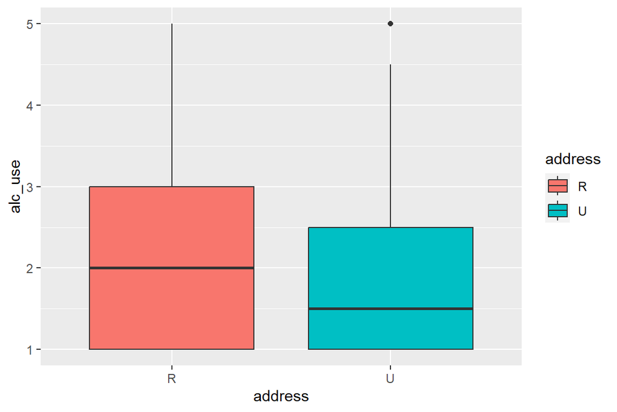

```r
g4 <- ggplot(alc, aes(x = address, y = alc_use, fill=address))+
  geom_boxplot()
g4
```

My hypothesis about rural living causing high alcohol consumption might well be correct!

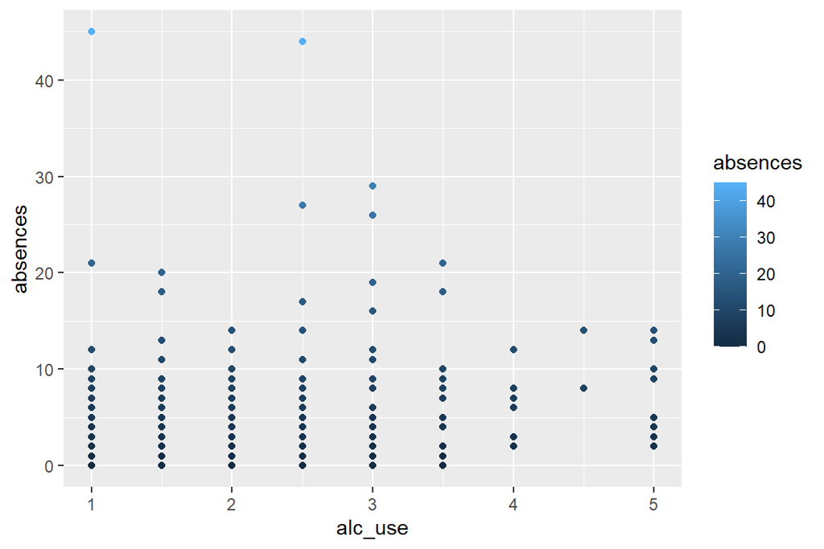

```r
g5 <- ggplot(alc, aes(x = alc_use, y = absences, color=absences))+
  geom_point()
g5
```

The alcohol consumption seems to be quite scattered around when plotted together with absences. No clear indication of my hypothesis being correct.

Logistic regression:

```r
m <- glm(high_use ~ age + sex + address + absences, data = alc, family = "binomial")
summary(m)
```

```
##
## Call:
## glm(formula = high_use ~ age + sex + address + absences, family = "binomial",
##     data = alc)
##
## Coefficients:
##             Estimate Std. Error z value Pr(>|z|)
## (Intercept) -3.71552    1.77325  -2.095   0.0361 *
## age          0.13172    0.10325   1.276   0.2020
## sexM         1.03363    0.24529   4.214 2.51e-05 ***
## addressU    -0.40391    0.28314  -1.427   0.1537
## absences     0.09333    0.02356   3.962 7.45e-05 ***
## ---
## Signif. codes:  0 '***' 0.001 '**' 0.01 '*' 0.05 '.' 0.1 ' ' 1
##
## (Dispersion parameter for binomial family taken to be 1)
##
##     Null deviance: 452.04  on 369  degrees of freedom
## Residual deviance: 411.27  on 365  degrees of freedom
## AIC: 421.27
##
## Number of Fisher Scoring iterations: 4
```

```r
coefficients(m)
```

```
## (Intercept)         age        sexM    addressU    absences
##  -3.7155227   0.1317217   1.0336294  -0.4039128   0.0933257
```

So, it seems that age and address are statistically insignificant, whereas male sex and high number of absences have statistically highly significant effect on alcohol consumption. Checking the odds ratios and confidence intervals:

```r
OR <- coef(m) %>% exp
CI <- confint(m)
cbind(OR, CI)
```

```
##                     OR       2.5 %     97.5 %
## (Intercept) 0.02434271 -7.24462192 -0.2732444
## age         1.14079079 -0.06972570  0.3361414
## sexM        2.81125045  0.55900936  1.5225186
## addressU    0.66770237 -0.95558085  0.1574767
## absences    1.09781924  0.04917901  0.1416402
```

Odds ratio being > 1, i.e. age, male sex, and absences, are positively correlated to alcohol consumption. Odds ratio for urban address is < 1, indicating that it would be negatively correlated. Confidence intervals reveal that age and address are statistically insignificant, whereas male sex and absences are significant. Making a new model with only statistically significant sex and absences included:

```r
m2 <- glm(high_use ~ absences + sex, data = alc, family = "binomial")
probabilities <- predict(m2, type = "response")
alc <- mutate(alc, probability = probabilities)
alc <- mutate(alc, prediction = probabilities)
select(alc, absences, sex, high_use, probability, prediction) %>% tail(10)
```

```
## # A tibble: 10 × 5
##    absences sex   high_use probability prediction
##       <dbl> <chr> <lgl>          <dbl>      <dbl>
##  1        3 M     FALSE          0.371      0.371
##  2        0 M     FALSE          0.306      0.306
##  3        7 M     TRUE           0.465      0.465
##  4        1 F     FALSE          0.147      0.147
##  5        6 F     FALSE          0.219      0.219
##  6        2 F     FALSE          0.160      0.160
##  7        2 F     FALSE          0.160      0.160
##  8        3 F     FALSE          0.173      0.173
##  9        4 M     TRUE           0.394      0.394
## 10        2 M     TRUE           0.349      0.349
```

```r
table(high_use = alc$high_use, prediction = probabilities)
```

[output not shown]

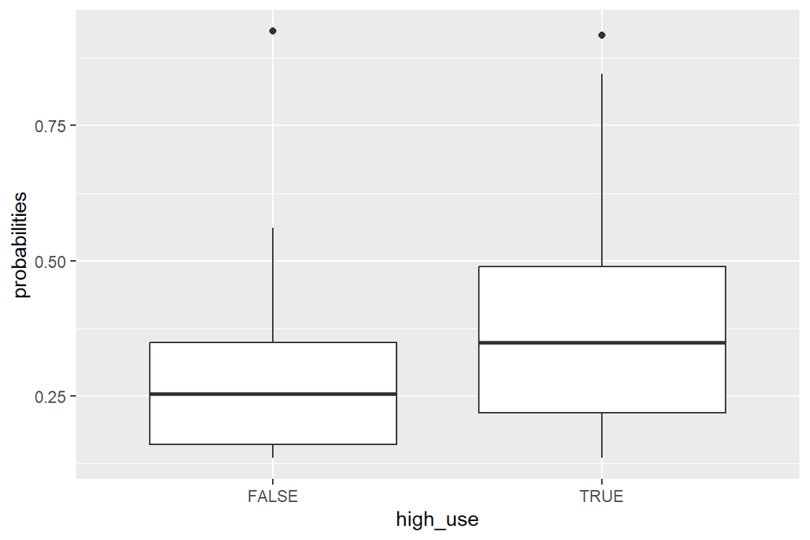

```r
g6 <- ggplot(alc, aes(x = high_use, y = probabilities))+
  geom_boxplot()
g6
```

```r
summary(m2)
```

```
##
## Call:
## glm(formula = high_use ~ absences + sex, family = "binomial",
##     data = alc)
##
## Coefficients:
##             Estimate Std. Error z value Pr(>|z|)
## (Intercept) -1.85303    0.22609  -8.196 2.49e-16 ***
## absences     0.09671    0.02336   4.140 3.48e-05 ***
## sexM         1.03451    0.24395   4.241 2.23e-05 ***
## ---
## Signif. codes:  0 '***' 0.001 '**' 0.01 '*' 0.05 '.' 0.1 ' ' 1
##
## (Dispersion parameter for binomial family taken to be 1)
##
##     Null deviance: 452.04  on 369  degrees of freedom
## Residual deviance: 415.66  on 367  degrees of freedom
## AIC: 421.66
##
## Number of Fisher Scoring iterations: 4
```

I’m not quite sure wheter I got the cross tabulation right. The second model looks good statistics-wise. Trying to compute the average number of wrong predictions:

```r
loss_func <- function(class, prob) {
  n_wrong <- abs(class - prob) > 0.5
  mean(n_wrong)
}
loss_func(class = alc$high_use, prob = 0)
```

```
## [1] 0.3
```